# lab-1#yash_suruneni

```python
import pandas as pd
# Read the csv file
credit = pd.read_csv("./credit.csv")
credit.head(4)
```

|  | Creditability | Account Balance | Duration of Credit (month) | Payment Status of Previous Credit | Purpose | Credit Amount | Value Savings/Stocks | Length of current employment | Instalment per cent | Sex & Marital Status | ... | Duration in Current address | Most valuable available asset | Age (years) | Concurrent Credits | Type of apartment | No of Credits at this Bank | Occupation | No of dependents | Telephone | Foreign Worker |
| --- | --- | --- | --- | --- | --- | --- | --- | --- | --- | --- | --- | --- | --- | --- | --- | --- | --- | --- | --- | --- | --- |
| 0 | 1 | 1 | 18 | 4 | 2 | 1049 | 1 | 2 | 4 | 2 | ... | 4 | 2 | 21 | 3 | 1 | 1 | 3 | 1 | 1 | 1 |
| 1 | 1 | 1 | 9 | 4 | 0 | 2799 | 1 | 3 | 2 | 3 | ... | 2 | 1 | 36 | 3 | 1 | 2 | 3 | 2 | 1 | 1 |
| 2 | 1 | 2 | 12 | 2 | 9 | 841 | 2 | 4 | 2 | 2 | ... | 4 | 1 | 23 | 3 | 1 | 1 | 2 | 1 | 1 | 1 |
| 3 | 1 | 1 | 12 | 4 | 0 | 2122 | 1 | 3 | 3 | 3 | ... | 2 | 1 | 39 | 3 | 1 | 2 | 2 | 2 | 1 | 2 |

4 rows × 21 columns

```python
credit.describe()
```

|  | Creditability | Account Balance | Duration of Credit (month) | Payment Status of Previous Credit | Purpose | Credit Amount | Value Savings/Stocks | Length of current employment | Instalment per cent | Sex & Marital Status | ... | Duration in Current address | Most valuable available asset | Age (years) | Concurrent Credits | Type of apartment | No of Credits at this Bank | Occupation | No of dependents | Telephone | Foreign Worker |
| --- | --- | --- | --- | --- | --- | --- | --- | --- | --- | --- | --- | --- | --- | --- | --- | --- | --- | --- | --- | --- | --- |
| count | 1000.000000 | 1000.000000 | 1000.000000 | 1000.00000 | 1000.000000 | 1000.00000 | 1000.000000 | 1000.000000 | 1000.000000 | 1000.00000 | ... | 1000.000000 | 1000.000000 | 1000.00000 | 1000.000000 | 1000.000000 | 1000.000000 | 1000.000000 | 1000.000000 | 1000.000000 | 1000.000000 |
| mean | 0.700000 | 2.577000 | 20.903000 | 2.54500 | 2.828000 | 3271.24800 | 2.105000 | 3.384000 | 2.973000 | 2.68200 | ... | 2.845000 | 2.358000 | 35.54200 | 2.675000 | 1.928000 | 1.407000 | 2.904000 | 1.155000 | 1.404000 | 1.037000 |
| std | 0.458487 | 1.257638 | 12.058814 | 1.08312 | 2.744439 | 2822.75176 | 1.580023 | 1.208306 | 1.118715 | 0.70808 | ... | 1.103718 | 1.050209 | 11.35267 | 0.705601 | 0.530186 | 0.577654 | 0.653614 | 0.362086 | 0.490943 | 0.188856 |
| min | 0.000000 | 1.000000 | 4.000000 | 0.00000 | 0.000000 | 250.00000 | 1.000000 | 1.000000 | 1.000000 | 1.00000 | ... | 1.000000 | 1.000000 | 19.00000 | 1.000000 | 1.000000 | 1.000000 | 1.000000 | 1.000000 | 1.000000 | 1.000000 |
| 25% | 0.000000 | 1.000000 | 12.000000 | 2.00000 | 1.000000 | 1365.50000 | 1.000000 | 3.000000 | 2.000000 | 2.00000 | ... | 2.000000 | 1.000000 | 27.00000 | 3.000000 | 2.000000 | 1.000000 | 3.000000 | 1.000000 | 1.000000 | 1.000000 |
| 50% | 1.000000 | 2.000000 | 18.000000 | 2.00000 | 2.000000 | 2319.50000 | 1.000000 | 3.000000 | 3.000000 | 3.00000 | ... | 3.000000 | 2.000000 | 33.00000 | 3.000000 | 2.000000 | 1.000000 | 3.000000 | 1.000000 | 1.000000 | 1.000000 |
| 75% | 1.000000 | 4.000000 | 24.000000 | 4.00000 | 3.000000 | 3972.25000 | 3.000000 | 5.000000 | 4.000000 | 3.00000 | ... | 4.000000 | 3.000000 | 42.00000 | 3.000000 | 2.000000 | 2.000000 | 3.000000 | 1.000000 | 2.000000 | 1.000000 |
| max | 1.000000 | 4.000000 | 72.000000 | 4.00000 | 10.000000 | 18424.00000 | 5.000000 | 5.000000 | 4.000000 | 4.00000 | ... | 4.000000 | 4.000000 | 75.00000 | 3.000000 | 3.000000 | 4.000000 | 4.000000 | 2.000000 | 2.000000 | 2.000000 |

8 rows × 21 columns

```python
credit.info()
```

```
<class 'pandas.core.frame.DataFrame'>
RangeIndex: 1000 entries, 0 to 999
Data columns (total 21 columns):
 #   Column                             Non-Null Count  Dtype
---  ------                             --------------  -----
 0   Creditability                      1000 non-null   int64
 1   Account Balance                    1000 non-null   int64
 2   Duration of Credit (month)         1000 non-null   int64
 3   Payment Status of Previous Credit  1000 non-null   int64
 4   Purpose                            1000 non-null   int64
 5   Credit Amount                      1000 non-null   int64
 6   Value Savings/Stocks               1000 non-null   int64
 7   Length of current employment       1000 non-null   int64
 8   Instalment per cent                1000 non-null   int64
 9   Sex & Marital Status               1000 non-null   int64
 10  Guarantors                         1000 non-null   int64
 11  Duration in Current address        1000 non-null   int64
 12  Most valuable available asset      1000 non-null   int64
 13  Age (years)                        1000 non-null   int64
 14  Concurrent Credits                 1000 non-null   int64
 15  Type of apartment                  1000 non-null   int64
 16  No of Credits at this Bank         1000 non-null   int64
 17  Occupation                         1000 non-null   int64
 18  No of dependents                   1000 non-null   int64
 19  Telephone                          1000 non-null   int64
 20  Foreign Worker                     1000 non-null   int64
dtypes: int64(21)
memory usage: 164.2 KB
```

```python
# storing the target in a new variable
target = credit['Creditability']
target.value_counts()
```

```
1    700
0    300
Name: Creditability, dtype: int64
```

```python
# Generate random numbers
# Method:1

import random
random.seed(12345)
indx = random.sample(range(0, 1000), 1000)
credit_rand = credit.iloc[indx]
target_rand = target.iloc[indx]

credit_rand.head(5)
```

|  | Creditability | Account Balance | Duration of Credit (month) | Payment Status of Previous Credit | Purpose | Credit Amount | Value Savings/Stocks | Length of current employment | Instalment per cent | Sex & Marital Status | ... | Duration in Current address | Most valuable available asset | Age (years) | Concurrent Credits | Type of apartment | No of Credits at this Bank | Occupation | No of dependents | Telephone | Foreign Worker |
| --- | --- | --- | --- | --- | --- | --- | --- | --- | --- | --- | --- | --- | --- | --- | --- | --- | --- | --- | --- | --- | --- |
| 426 | 1 | 2 | 39 | 3 | 6 | 11760 | 2 | 4 | 2 | 3 | ... | 3 | 4 | 32 | 3 | 1 | 1 | 3 | 1 | 2 | 1 |
| 750 | 1 | 2 | 36 | 3 | 0 | 2862 | 2 | 5 | 4 | 3 | ... | 3 | 4 | 30 | 3 | 3 | 1 | 3 | 1 | 1 | 1 |
| 10 | 1 | 1 | 11 | 4 | 0 | 3905 | 1 | 3 | 2 | 3 | ... | 2 | 1 | 36 | 3 | 1 | 2 | 3 | 2 | 1 | 1 |
| 839 | 0 | 4 | 12 | 2 | 0 | 1386 | 3 | 3 | 2 | 2 | ... | 2 | 2 | 26 | 3 | 2 | 1 | 3 | 1 | 1 | 1 |
| 845 | 0 | 2 | 27 | 4 | 3 | 2520 | 3 | 3 | 4 | 3 | ... | 2 | 2 | 23 | 3 | 2 | 2 | 2 | 1 | 1 | 1 |

5 rows × 21 columns

```python
credit_rand.describe()
```

|  | Creditability | Account Balance | Duration of Credit (month) | Payment Status of Previous Credit | Purpose | Credit Amount | Value Savings/Stocks | Length of current employment | Instalment per cent | Sex & Marital Status | ... | Duration in Current address | Most valuable available asset | Age (years) | Concurrent Credits | Type of apartment | No of Credits at this Bank | Occupation | No of dependents | Telephone | Foreign Worker |
| --- | --- | --- | --- | --- | --- | --- | --- | --- | --- | --- | --- | --- | --- | --- | --- | --- | --- | --- | --- | --- | --- |
| count | 1000.000000 | 1000.000000 | 1000.000000 | 1000.00000 | 1000.000000 | 1000.00000 | 1000.000000 | 1000.000000 | 1000.000000 | 1000.00000 | ... | 1000.000000 | 1000.000000 | 1000.00000 | 1000.000000 | 1000.000000 | 1000.000000 | 1000.000000 | 1000.000000 | 1000.000000 | 1000.000000 |
| mean | 0.700000 | 2.577000 | 20.903000 | 2.54500 | 2.828000 | 3271.24800 | 2.105000 | 3.384000 | 2.973000 | 2.68200 | ... | 2.845000 | 2.358000 | 35.54200 | 2.675000 | 1.928000 | 1.407000 | 2.904000 | 1.155000 | 1.404000 | 1.037000 |
| std | 0.458487 | 1.257638 | 12.058814 | 1.08312 | 2.744439 | 2822.75176 | 1.580023 | 1.208306 | 1.118715 | 0.70808 | ... | 1.103718 | 1.050209 | 11.35267 | 0.705601 | 0.530186 | 0.577654 | 0.653614 | 0.362086 | 0.490943 | 0.188856 |
| min | 0.000000 | 1.000000 | 4.000000 | 0.00000 | 0.000000 | 250.00000 | 1.000000 | 1.000000 | 1.000000 | 1.00000 | ... | 1.000000 | 1.000000 | 19.00000 | 1.000000 | 1.000000 | 1.000000 | 1.000000 | 1.000000 | 1.000000 | 1.000000 |
| 25% | 0.000000 | 1.000000 | 12.000000 | 2.00000 | 1.000000 | 1365.50000 | 1.000000 | 3.000000 | 2.000000 | 2.00000 | ... | 2.000000 | 1.000000 | 27.00000 | 3.000000 | 2.000000 | 1.000000 | 3.000000 | 1.000000 | 1.000000 | 1.000000 |
| 50% | 1.000000 | 2.000000 | 18.000000 | 2.00000 | 2.000000 | 2319.50000 | 1.000000 | 3.000000 | 3.000000 | 3.00000 | ... | 3.000000 | 2.000000 | 33.00000 | 3.000000 | 2.000000 | 1.000000 | 3.000000 | 1.000000 | 1.000000 | 1.000000 |
| 75% | 1.000000 | 4.000000 | 24.000000 | 4.00000 | 3.000000 | 3972.25000 | 3.000000 | 5.000000 | 4.000000 | 3.00000 | ... | 4.000000 | 3.000000 | 42.00000 | 3.000000 | 2.000000 | 2.000000 | 3.000000 | 1.000000 | 2.000000 | 1.000000 |
| max | 1.000000 | 4.000000 | 72.000000 | 4.00000 | 10.000000 | 18424.00000 | 5.000000 | 5.000000 | 4.000000 | 4.00000 | ... | 4.000000 | 4.000000 | 75.00000 | 3.000000 | 3.000000 | 4.000000 | 4.000000 | 2.000000 | 2.000000 | 2.000000 |

8 rows × 21 columns

```python
# segregating train and test data

credit_train = credit_rand.iloc[0:700]
credit_test = credit_rand.iloc[700:1000]
target_train = target_rand.iloc[0:700]
target_test = target_rand.iloc[700:1000]

# target train

target_train.value_counts()/700
```

```
1    0.691429
0    0.308571
Name: Creditability, dtype: float64
```

```python
# target test

target_test.value_counts()/300
```

```
1    0.72
0    0.28
Name: Creditability, dtype: float64
```

```python
# method - 2 using scikit

from sklearn.model_selection import train_test_split
y = target
X = credit.drop(['Creditability'],axis=1)
X_train, X_test, y_train, y_test = train_test_split(X, y, test_size=0.30,
random_state=52)
```

```python
# Training the model

from sklearn import tree
from sklearn.tree import DecisionTreeClassifier
model = tree.DecisionTreeClassifier()
model = model.fit(X_train, y_train)


from IPython.display import SVG
from graphviz import Source
from IPython.display import display
graph = Source(tree.export_graphviz(model, out_file=None , feature_names=X.columns, class_names=['default', 'no default'] , filled = True))
display(SVG(graph.pipe(format='svg')))
```

[figure not shown]

```python
# Evaluating model performance

from sklearn.metrics import confusion_matrix
from sklearn.metrics import accuracy_score

y_predict = model.predict(X_test)

print(confusion_matrix(y_test, y_predict))
print(accuracy_score(y_test, y_predict)*100)
```

```
[[ 41  43]
 [ 54 162]]
67.66666666666666
```

Q1: - If you see the accuracy 0f 100%, what does it mean? Does this mean that we design a perfect model? This is some thing that needs more discussion. Write a few sentences about accuracy of 100%. ?

Answer:

If the accuracy is 100% , that means the model is overfitting.

Overfitting:

The model can keep asking questions until all the nodes are pure. Pure nodes include data points from only one class. The model can keep asking questions (or splitting data) until all the leaf nodes are pure. However, this would be a too specific model and would not generalize well. It achieves high accuracy with training set but performs poorly on new, previously unseen data points.

It is very important to control or limit the depth of a tree to prevent overfitting.

Pre-Pruning (Early Stopping Rule):

Stop if all instances belong to the same class. Stop if all the attribute values are the same. Stop if number of instances is less than some user-specified threshold. Stop if class distribution of instances are independent of the available features. Stop if expanding the current node does not improve impurity measures

Post-Pruning:

Grow decision tree to its entirety. Trim the nodes of the decision tree in a bottom-up fashion. If generalization error improves after trimming, replace sub-tree by a leaf node. Class label of leaf node is determined from majority class of instances in the sub-tree.

Scikit-learn provides hyperparameters like max_depth , min_samples_split , min_impurity_decrease to control the structure of decision trees.

```python
# Random Forest
from sklearn.ensemble import RandomForestClassifier
clf = RandomForestClassifier()
clf.fit(X_train, y_train)
y_predict = clf.predict(X_test)
print(confusion_matrix(y_test, y_predict))
print(accuracy_score(y_test, y_predict)*100)
```

```
[[ 37  47]
 [ 30 186]]
74.33333333333333
```

Q2: What are the three most important features in this model. Also change the random seed to 23458 and find the new accuracy of random forest

```python
import pandas as pd
feature_importances = pd.DataFrame(clf.feature_importances_,index = X_train.columns,
columns=['importance']).sort_values('importance',ascending=False)
feature_importances
```

|  | importance |
| --- | --- |
| Credit Amount | 0.132809 |
| Account Balance | 0.109255 |
| Age (years) | 0.108913 |
| Duration of Credit (month) | 0.107754 |
| Purpose | 0.061815 |
| Payment Status of Previous Credit | 0.056074 |
| Length of current employment | 0.053651 |
| Value Savings/Stocks | 0.050999 |
| Sex & Marital Status | 0.040138 |
| Most valuable available asset | 0.039915 |
| Instalment per cent | 0.039680 |
| Duration in Current address | 0.038464 |
| Occupation | 0.033293 |
| Type of apartment | 0.027813 |
| Guarantors | 0.021798 |
| Concurrent Credits | 0.021701 |
| No of Credits at this Bank | 0.019945 |
| Telephone | 0.017091 |
| No of dependents | 0.014704 |
| Foreign Worker | 0.004187 |

```python
import numpy as np
from sklearn.feature_selection import SelectFromModel
from sklearn.linear_model import LassoCV

clf = LassoCV().fit(X, y)
importance = np.abs(clf.coef_)

print(importance)

idx_third = importance.argsort()[-4]
threshold = importance[idx_third] + 0.01

idx_features = (-importance).argsort()[:3]
print(idx_features)

name_features = np.array(list(credit.columns.values))[idx_features]

print('Most important features: {}'.format(name_features))
```

```
[0.00000000e+00 4.94068645e-03 0.00000000e+00 0.00000000e+00
 1.21810660e-05 0.00000000e+00 0.00000000e+00 0.00000000e+00
 0.00000000e+00 0.00000000e+00 0.00000000e+00 0.00000000e+00
 2.03293478e-03 0.00000000e+00 0.00000000e+00 0.00000000e+00
 0.00000000e+00 0.00000000e+00 0.00000000e+00 0.00000000e+00]
[ 1 12  4]
Most important features: ['Account Balance' 'Most valuable available asset' 'Purpose']
```

```python
from sklearn.model_selection import train_test_split
y = target
X = credit[name_features]
X_train, X_test, y_train, y_test = train_test_split(X, y, test_size=0.30, random_state=23458)
from sklearn.ensemble import RandomForestClassifier
clf = RandomForestClassifier()
clf.fit(X_train, y_train)
y_predict = clf.predict(X_test)
print(confusion_matrix(y_test, y_predict))
print(accuracy_score(y_test, y_predict)*100)
```

```
[[ 39  43]
 [ 42 176]]
71.66666666666667
```

Method #3. Adding regression to trees , using whitewines dataset

```python
input_file = "./whitewines.csv"
wine = pd.read_csv(input_file)
wine.head(5)
```

|  | fixed acidity | volatile acidity | citric acid | residual sugar | chlorides | free sulfur dioxide | total sulfur dioxide | density | pH | sulphates | alcohol | quality |
| --- | --- | --- | --- | --- | --- | --- | --- | --- | --- | --- | --- | --- |
| 0 | 6.7 | 0.62 | 0.24 | 1.10 | 0.039 | 6.0 | 62.0 | 0.99340 | 3.41 | 0.32 | 10.400000 | 5 |
| 1 | 5.7 | 0.22 | 0.20 | 16.00 | 0.044 | 41.0 | 113.0 | 0.99862 | 3.22 | 0.46 | 8.900000 | 6 |
| 2 | 5.9 | 0.19 | 0.26 | 7.40 | 0.034 | 33.0 | 123.0 | 0.99500 | 3.49 | 0.42 | 10.100000 | 6 |
| 3 | 5.3 | 0.47 | 0.10 | 1.30 | 0.036 | 11.0 | 74.0 | 0.99082 | 3.48 | 0.54 | 11.200000 | 4 |
| 4 | 6.4 | 0.29 | 0.21 | 9.65 | 0.041 | 36.0 | 119.0 | 0.99334 | 2.99 | 0.34 | 10.933333 | 6 |

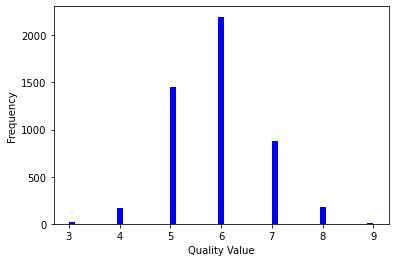

```python
# Plot the target variable import matplotlib.pyplot as plt
# An "interface" to matplotlib.axes.Axes.hist() method
import matplotlib.pyplot as plt
n, bins, patches = plt.hist(x=wine['quality'], bins='auto', color='b')
plt.xlabel('Quality Value')
plt.ylabel('Frequency')
plt.show()
```

```python
from sklearn.model_selection import train_test_split
y = wine['quality']
X = wine.drop(['quality'],axis=1)
X_train, X_test, y_train, y_test = train_test_split(X, y, test_size=0.30,
random_state=52)

# Design decision tree from sklearn import tree
from sklearn.tree import DecisionTreeClassifier
model = tree.DecisionTreeClassifier()
model = model.fit(X_train, y_train)
```

```python
# visualize the wine model and export into tree file

from IPython.display import SVG
from IPython.display import display
from sklearn.tree import export_graphviz

export_graphviz(model, out_file ='tree.dot', feature_names =X.columns)

from graphviz import Source
dot_data = tree.export_graphviz(model, out_file=None, feature_names=X.columns, filled=True, rounded=True, special_characters=True)
graph = Source(dot_data)
graph
```

[figure not shown]

```python
# predicting model performance

from sklearn.metrics import confusion_matrix
from sklearn.metrics import accuracy_score
y_predict = model.predict(X_test)
print(confusion_matrix(y_test, y_predict))
print(accuracy_score(y_test, y_predict)*100)
```

```
[[  0   1   4   0   1   0   0]
 [  0  10  18  10   0   1   0]
 [  2  21 260 127  22   1   0]
 [  3  16 132 423  70  16   1]
 [  0   1  26  81 153  10   2]
 [  0   0   2  17  16  21   1]
 [  0   0   0   1   0   0   0]]
58.97959183673469
```

```python
# correlation
np.corrcoef(y_test,y_predict)
```

```
array([[1.        , 0.54288388],
       [0.54288388, 1.        ]])
```

```python
#RMSE

from sklearn.metrics import mean_squared_error
from math import sqrt

rmse = sqrt(mean_squared_error(y_test,y_predict))

print(rmse)
```

```
0.8451542547285166
```

Q3- What is your interpretation about this amount of RMSE?

The RMSE ( Root Mean Square Error Value ) is always in the units of the target value, Here we are trying to predict the quality whose value ranges between 3 to 9. The RMSE value of 0.85 is quite high.

The RMSE value will depend on our choice of units, and on the specific application. for example 100 inches is a big error in a building design, but 100 nanometers is not. On the other hand, 100 nanometers is a small error in fabricating an ice cube tray, but perhaps a big error in fabricating an integrated circuit.

NEWS POPULARITY

```python
import pandas as pd
# Read the csv file
news = pd.read_csv("./NewsPopularity.csv")
news.head(4)
```

|  | url | timedelta | n_tokens_title | n_tokens_content | n_unique_tokens | n_non_stop_words | n_non_stop_unique_tokens | num_hrefs | num_self_hrefs | num_imgs | ... | min_positive_polarity | max_positive_polarity | avg_negative_polarity | min_negative_polarity | max_negative_polarity | title_subjectivity | title_sentiment_polarity | abs_title_subjectivity | abs_title_sentiment_polarity | shares |
| --- | --- | --- | --- | --- | --- | --- | --- | --- | --- | --- | --- | --- | --- | --- | --- | --- | --- | --- | --- | --- | --- |
| 0 | http://mashable.com/2013/01/07/amazon-instant-... | 731 | 12 | 219 | 0.663594 | 1.0 | 0.815385 | 4 | 2 | 1 | ... | 0.100000 | 0.7 | -0.350000 | -0.600 | -0.200000 | 0.5 | -0.1875 | 0.0 | 0.1875 | 593 |
| 1 | http://mashable.com/2013/01/07/ap-samsung-spon... | 731 | 9 | 255 | 0.604743 | 1.0 | 0.791946 | 3 | 1 | 1 | ... | 0.033333 | 0.7 | -0.118750 | -0.125 | -0.100000 | 0.0 | 0.0000 | 0.5 | 0.0000 | 711 |
| 2 | http://mashable.com/2013/01/07/apple-40-billio... | 731 | 9 | 211 | 0.575130 | 1.0 | 0.663866 | 3 | 1 | 1 | ... | 0.100000 | 1.0 | -0.466667 | -0.800 | -0.133333 | 0.0 | 0.0000 | 0.5 | 0.0000 | 1500 |
| 3 | http://mashable.com/2013/01/07/astronaut-notre... | 731 | 9 | 531 | 0.503788 | 1.0 | 0.665635 | 9 | 0 | 1 | ... | 0.136364 | 0.8 | -0.369697 | -0.600 | -0.166667 | 0.0 | 0.0000 | 0.5 | 0.0000 | 1200 |

4 rows × 61 columns

```python
from sklearn.preprocessing import LabelEncoder
from sklearn.model_selection import train_test_split
from sklearn.model_selection import cross_val_score
from sklearn import metrics
from sklearn.ensemble import RandomForestClassifier
X = news[0:58]
Y = news['shares']
```

```python
# get the statistics of original attributes
data = news[news.keys()[-1]]
data.describe()
# Encode the label by threshold 1400
from sklearn import preprocessing
label_encoder = preprocessing.LabelEncoder()
popular_label = pd.Series(label_encoder.fit_transform(data>=1400))
```

```python
popular = news.shares >= 1400
unpopular = news.shares < 1400
news.loc[popular,'shares'] = 1
news.loc[unpopular,'shares'] = 0
```

```python
features=list(news.columns[2:60])
```

```python
# split dataset to 70-30 training and testing resp.
X_train, X_test, y_train, y_test = train_test_split(news[features], news['shares'], test_size=0.30 ,random_state=23458)

#Shape of  training and test datasets
print(X_train.shape)
print(y_train.shape)
```

```
(27750, 58)
(27750,)
```

```python
# Design decision tree
from sklearn import tree
from sklearn.tree import DecisionTreeClassifier
model = tree.DecisionTreeClassifier()
model = model.fit(X_train, y_train)
```

```python
#Decision Tree model and accuracy
from sklearn.metrics import confusion_matrix
from sklearn.metrics import accuracy_score

y_predict = model.predict(X_test)
print(confusion_matrix(y_test, y_predict))
print("Accuracy Score using decision tree")
print(accuracy_score(y_test, y_predict)*100)
```

[output not shown]

```python
# Random forest and accuracy
from sklearn.ensemble import RandomForestClassifier
clf = RandomForestClassifier()
clf.fit(X_train, y_train)
y_predict = clf.predict(X_test)
print(confusion_matrix(y_test, y_predict))
print("Accuracy Score using random forest")
print(accuracy_score(y_test, y_predict)*100)
```

```
[[3387 2136]
 [1803 4568]]
Accuracy Score using random forest
66.88246174541786
```